# Selection and Assessment of Machine Learning Models

May 9, 2018

## Overview of the problem

- `Model Selection`
  - Examine different model and choose the best one
- `Model Assessment`
  - Estimate the prediction error on new data
- If data is large, divide it into three parts
  - Training set (50%) to fit model
  - Validation set (25%) to select model
  - Test set (25%) to assess model

## General Supervised Learning Model

- \(X \in \mathbb R^p\) is a real valued random input vector
- \(Y \in \mathbb R\) output variable
- We seek to find a function \(f(X)\) that can predict \(Y\)
  - This is done by minimizing the loss function \(L(Y,f(X))\)
- The problem selecting a model is to find \(f(X)\)
  - parametric or non-parametric
  - linear or non-linear
  - additive or non-additive error
  - which loss function is to pick. Squared, absolute, exponential etc.

## Example: Model Selection

- Squared error loss function \(L(Y, f(X)) = (Y - f(X))^2\)
- Expected Prediction Error \(EPE(f) = E_X E_{Y|X} ((Y, f(X))^2 |X)\)
- Minimizing \(EPE(f)\) gives the solution \(f(x) = E(Y|X=x)\)
  - this is basically regression function
- Nearest-neighborhood method can implement this idea by
  - approximating expectation by sample average
  - relaxing the condition on some region close to target x
  - so we have \[\hat f(x) = Ave(y_i|x \in N_k(x_i))\]

## Expected Training Error Rate

- Suppose we have a training data set \[\tau = \{(y_1,x_2), (y_2,x_2),..., (y_N,x_N)\}\]
- Error for new data set \((Y^0,X^0)\)
  - \(Err_{\tau} = E[L(Y^0, \hat f(X^0))|\tau]\)
  - where \(L(.)\) could be squared or absolute loss
  - it is a function of training data \(\tau\)
- Finally expected error
  - \(Err = E_{\tau}E[L(Y^0, \hat f(X^0))|\tau]\)

## Optimism

- Observed training error
  - \(\bar {err} = \frac 1 N \sum_i L(y_i,\hat f(x_i))\)
  - typically \(\bar {err} < Err_{\tau}\) since sample data is used twice in observed error
- In sample error
  - \(Err_{in} = \frac 1 N \sum _i L(Y^0_i,\hat f(x_i))\)
  - \(Y^0\) is new set of data for \(X\) that coincide with the training data
- Optimism is defined
  - \(op = Err_{in} - \bar {err}\)
  - expected optimism is \(\omega = E_y(op)\)
  - its the amount by which \(\bar {err}\) under estimates true error

## In-sample Error Rate

- For squared error loss function \(L(.)\) we have expected optimism \[\omega = \frac 2 N \sum Cov(\hat y_i, y_i)\]
- Thus we have the following relationship \[E_y(Err_{in}) = E_y(\bar{err}) + \frac 2 N \sum Cov(\hat y_i, y_i)\]
- For an additive model \(Y = f(X) + \epsilon\) it simplifies to \[E_y(Err_{in}) = E_y(\bar{err}) + 2 \frac d N \sigma^2_{\epsilon}\]
- We can estimate it as \(\hat {Err}_{in} = \bar{err} + \hat{\omega}\)

## Error estimate

- For squared error loss function, when number of parameters is \(d\) we have \[C_p = \bar{err} + 2 \frac d N \hat {\sigma}^2\]
- When log likelihood loss function is used, ie \(loglik = \sum_i log Pr_{\hat{\theta}}(y_i)\) we have Akaike Information Criteria \[AIC = -\frac 2 N loglik + 2 \frac d N\]
- Bayesian Information Criteria is \[BIC = -2 loglik + (log N) d\]

## Which Measure to Rely on

- You can use both BIC and AIC for model selection
- `BIC` tends to select correct model as \(N \rightarrow \infty\)
  - one problem is that it often pick too simple model
- `AIC` tends to pick more complex model as less penalty is given for complexity
- Other methods for model selection includes
  - Minimum Description Length `MDL`; picks simpler model but approach is different from BIC
  - Structured Risk Minimization `SRM`; fits nested sequences of models picks model with minimum upper bound of error
- Read chapter 7 for more discussion on these

## \(K\)-fold Cross Validation

- Part of the data is used to fit the model, different part is to test
- For \(K=5\) the scenario looks like

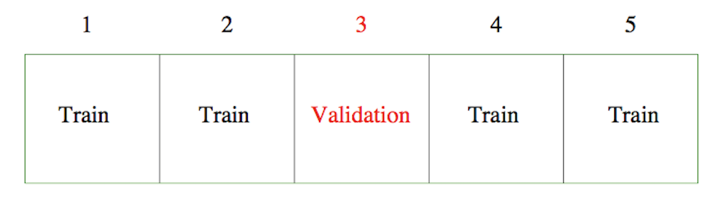

- Model fitted with \(k\)th data part removed and repeated for all \(k=1,2, ..., K\)
- Cross validation estimate of prediction error is \(CV(\hat f) =\frac 1 N \sum L(y_i,\hat f^{-k}(x_i))\)
- When \(K=N\), it is called leave-one-out cross validation
- Provides an idea about the distribution of prediction error and hence help select models

## Bootstrap Method

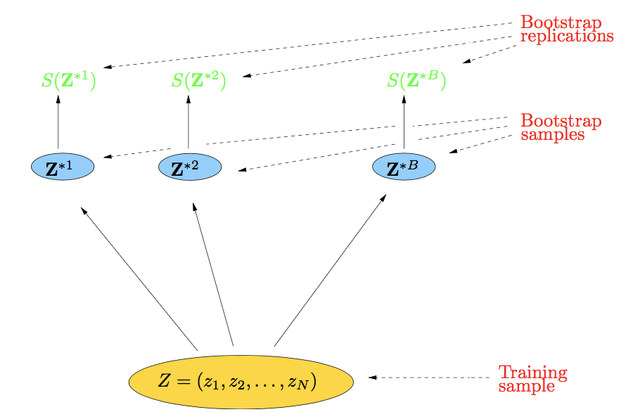

- Bootstrap prediction error \(\bar Err_{boot} = \frac 1 B \frac 1N \sum_b \sum_i L(y_i,\hat f^b(x_i))\)

## Statistical Inference

- Inference for supervised learning models can be done by
  - Bootstrap
  - Maximum Likelihood
- Inference for un-supervised learning is
  - tricky
  - Visual inference can be applied

## Maximum Likelihood inference

- Suppose observation is obtained as \(z_i \sim g_{\theta}(z)\)
  - likelihood function is \(\ell(\theta;Z)= \sum log [g_{\theta}(z_i)]\)
  - MLE \(\hat {\theta}\) is obtained by maximizing \(\ell\)
  - Information matrix \(I(\theta) = -\sum \frac{\partial^2 \ell(\theta;z_i)}{\partial\theta \partial \theta^T}\) provides variance estimates
  - \(\hat {\theta}\) has a limiting normal distribution. \(\hat{\theta} \sim N(\hat {\theta},i(\hat{\theta})^{-1})\) approximately
  - \((1-\alpha)100%\) CI of \(\theta_j\) be \(\hat{\theta}_j \pm z^(1-\alpha)\sqrt{i(\hat{\theta})^{-1}_{jj}}\)

## Other Methods for Inference

- Maximum Likelihood is a parametric method
  - other parametric method is Bayesian method and MCMC
  - Bootstrap can be used for both parametric and non-parametric situations
- bagging is the estimation by averaging over bootstrap samples
  - bagged estimate \(\hat f_{bag}(x) = \frac 1 B \sum_b\hat f^b(x)\)
- For testing non-parametric hypothesis visual inference can be applied

## Reading and References

- Chapters 2, 7 and 8, The Elements of Statistical Learning by Hastie at el.